# Writing reports in Rmarkdown (HTML version)

Daniel Hammarström

7 11 2021

# 1 Introduction

- R Markdown documents are source documents combining code and text into reproducible reports.
- R Markdown can be converted to multiple output formats including HTML, word and PDF. These outputs have several other options to produce presentations, books or simple reports.
- Reports can be customized to fit requirements for your thesis or paper.

# 2 Basics

## 2.1 YAML and bibliography

- The YAML field lets you specify options for your output file. Not all fields will be read by your output. A simple example that produces the `title`, `author`, `date` and sets the output format of this document (`output`).

```r
---
title: "Writing reports in Rmarkdown (HTML version)"
author: "Daniel Hammarström"
date: "7 11 2021"
output: html_document
---
```

- The YAML field is used to specify the bibliography. This is a file containing references in a format compatible with the reference engine, usually in bibtex format.
- To add a bibliography, specify `bibliography:` with the path to your bibliography.

```r
---
title: "Writing reports in Rmarkdown (HTML version)"
author: "Daniel Hammarström"
date: "7 11 2021"
output: html_document
bibliography: resources/references.bib
---
```

- In the file `references.bib` a bibtex reference is created such as:

```r
@article{hammarström2020,
    title = {Benefits of higher resistance-training volume are related to ribosome biogenesis},
    author = {{Hammarström}, {Daniel} and {Øfsteng}, {Sjur} and {Koll}, {Lise} and {Hanestadhaugen}, {Marita} and {Hollan}, {Ivana} and {Apró}, {William} and {Whist}, {Jon Elling} and {Blomstrand}, {Eva} and {Rønnestad}, {Bent R.} and {Ellefsen}, {Stian}},
    year = {2020},
    date = {2020},
    journal = {The Journal of physiology},
    pages = {543--565},
    volume = {598},
    number = {3},
    doi = {10.1113/JP278455},
    url = {https://www.ncbi.nlm.nih.gov/pubmed/31813190 https://physoc.onlinelibrary.wiley.com/doi/full/10.1113/JP278455},
    note = {Edition: 2020/01/15},
    langid = {eng}
}
```

- If you have Zotero installed, adding references is as easy as opening the visual markdown editor and add citation.
- In the final report, citations will look e.g. like this (1,2). This is the result of writing `[@hammarström2020;@wen2016]` in your markdown document.
- Your references must be in your `references.bib` file. If using the plug-in, new references will be updated to the file as you reference.

## 2.2 Changing the citation style

- Citation styles exists in many different shapes (e.g. (Wen 2016), [2], (2), <sup>2</sup>)
- To change the citation style in an R Markdown document you may add a custom csl-file. Citation style language (CSL) is, as the name implies a language for citation styles. Find more information [here](https://citationstyles.org/authors/).
- Citation styles can be downloaded from the github folder https://github.com/citation-style-language/styles. Copy the code from github into a new file and store it in your resources folder. Add `csl: resources/vancouver.csl` to your YAML:

```r
---
title: "Writing reports in Rmarkdown (HTML version)"
author: "Daniel Hammarström"
date: "7 11 2021"
output:
  bookdown::html_document2: default
bibliography: resources/references.bib
csl: resources/vancouver.csl
---
```

## 2.3 Cross-referencing

- You can use cross-referencing inside documents to refer to figures, tables and headlines.
- Cross-referencing works when setting the output to `html_document2` in the YAML field, this output is specified in the `bookdown` package so the YAML field will havce to look like this:

```r
---
title: "Writing reports in Rmarkdown (HTML version)"
author: "Daniel Hammarström"
date: "7 11 2021"
output:
  bookdown::html_document2: default
bibliography: resources/references.bib
---
```

- To cross-reference a figure, you also have to name the code-chunk producing the figure, e.g. `{r figure-1}`.
- You may now reference the figure using `\@ref(fig:figure-1)`. The reference will appear as a number (see Figure 2.1) and the figure will be automatically numbered.

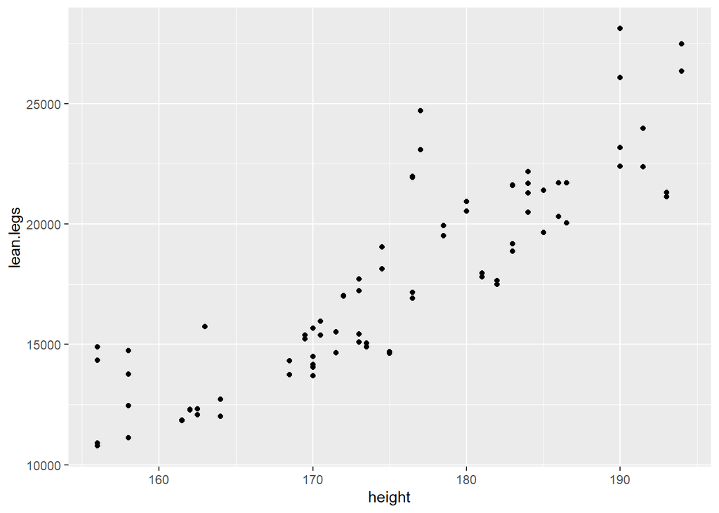

Figure 2.1: An example caption

```r
library(tidyverse);library(exscidata)
data(dxadata)

dxadata %>%
  ggplot(aes(height, lean.legs)) + geom_point()
```

- Similarly, tables can also be referenced but the need another type `\@ref(table:table-1)`
- Headers can be referenced using e.g. `[see References](#refs)` where `#refs` is a id that I have put after the References heading below. This will produce (see References).

## 2.4 Including HTML

- Since the report engine converts your document to HTML you may add HTML code. E.g. if you would like to embed a youtube clip it is as simple as copying the code from youtube to your document.

```r
<iframe width="560" height="315" src="https://www.youtube-nocookie.com/embed/_DhOMdcbjuU" frameborder="0" allowfullscreen></iframe>
```

[video not shown]

# 3 Exercises

1. Define a new R project and create a R Markdown file.
2. Organize the project folder and add a file containing bibtex citations, write some text and add a citation.
3. Explore the CSL github repository and change your csl format.
4. Add a figure and a table (`kable`) to the document, cross-reference both.

# References

1.

Hammarström D, Øfsteng S, Koll L, Hanestadhaugen M, Hollan I, Apró W, et al. Benefits of higher resistance-training volume are related to ribosome biogenesis. The Journal of physiology [Internet]. 2020;598(3):543–65. Available from: https://www.ncbi.nlm.nih.gov/pubmed/31813190 https://physoc.onlinelibrary.wiley.com/doi/full/10.1113/JP278455

2.

Wen Y, Alimov AP, McCarthy JJ. Ribosome biogenesis is necessary for skeletal muscle hypertrophy. Exerc Sport Sci Rev [Internet]. 2016 Apr 29; Available from: http://www.ncbi.nlm.nih.gov/pubmed/27135313